# s3e_build

This file merges data from different files in preparation for analyses

```python
import pandas as pd          # pandas: main library for tabular data (DataFrames)
import numpy as np            # numpy: numerical computing, arrays, math functions
import os                     # os: interact with the operating system (file paths, folders)
import matplotlib.pyplot as plt  # pyplot: plotting functions (charts, figures)

d = f"{os.getcwd()}/"        # os.getcwd() returns the current working directory as a string; f"..." is an f-string that embeds it
PATH_RAW = os.path.join(d, "..", "raw")   # raw inputs (downloads / intermediate CSVs)
PATH_DATA = os.path.join(d, "..", "data")    # processed modeling tables
# os.path.join() safely builds file paths by joining folder parts (works on Windows and Mac/Linux)
# ".." means "go up one folder level"
PATH_OUTPUT = os.path.join(d, "..", "output")
# Output folder for model results (forecasts, performance tables)
# Create folder if it does not exist
os.makedirs(PATH_OUTPUT, exist_ok=True)   # exist_ok=True prevents an error if the folder already exists
data_file = "data.csv"
meta_file = "meta.csv"

# pd.read_csv() reads a CSV file into a DataFrame; index_col sets the row index; parse_dates converts strings to datetime
df = pd.read_csv(f"{PATH_DATA}/{data_file}" , index_col='date', parse_dates=True)

df.head(5)    # .head(n) shows the first n rows — useful for a quick preview
```

| date | RGDP0000 | UMBL0000 | MLIA1001 | MLIA1002 | MLIA1003 | MLIA1004 | MLIA1000 | MLIA0003 | MLIA0002 | MLIA0004 | ... | UNTL1001 | UNTL1002 | UNTL1003 | UNTL1004 | UNTL1005 | UNTL1006 | UNTL1007 | UNTL1008 | UNTL0000 | UGTR0000 |
| --- | --- | --- | --- | --- | --- | --- | --- | --- | --- | --- | --- | --- | --- | --- | --- | --- | --- | --- | --- | --- | --- |
| 2015-02-01 | NaN | 54304.080413 | 31890.278 | 135559.643 | 249451.351 | 116008.373 | 532909.645 | 52036.644 | 1501.182 | 14318.718 | ... | NaN | NaN | NaN | NaN | NaN | NaN | NaN | NaN | NaN | 32.586207 |
| 2015-03-01 | 376071.0 | 55526.300906 | 29976.701 | 127010.461 | 245889.630 | 112828.497 | 515705.289 | 56535.456 | 588.502 | 13734.467 | ... | 19.581647 | 23.877658 | 20.174278 | 13.762500 | 8.753688 | 30.493850 | 9.522143 | 30.088176 | 1.674579 | 32.607143 |
| 2015-04-01 | NaN | 59615.749986 | 29459.217 | 130600.536 | 249975.925 | 124345.188 | 534380.866 | 45095.208 | 1278.866 | 14176.166 | ... | NaN | NaN | NaN | NaN | NaN | NaN | NaN | NaN | NaN | 33.103448 |
| 2015-05-01 | NaN | 59716.660777 | 31062.846 | 131010.962 | 250064.108 | 123469.817 | 535607.733 | 76705.413 | 1184.963 | 14060.821 | ... | 18.828774 | 24.003975 | 18.313966 | 11.701691 | 8.817571 | 28.589780 | 9.731429 | 27.951169 | 1.576283 | 32.428571 |
| 2015-06-01 | 371294.0 | 67004.537620 | 33260.686 | 138340.931 | 252099.208 | 120679.419 | 544380.244 | 76448.591 | 564.249 | 13772.059 | ... | 20.043456 | 25.087085 | 21.467273 | 15.063125 | 8.860380 | 31.198321 | 10.194286 | 29.355244 | 1.494259 | 35.821429 |

5 rows × 1004 columns

The dataset includes the output variable, GDP

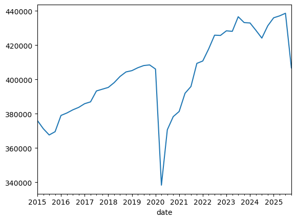

```python
df['RGDP0000'].dropna().plot()   # select one column, drop missing values, then plot it as a line chart
```

We wish to include **google trends** and **nighttime lights** data on our main data

First, let's keep only GDP.

```python
df = df[['RGDP0000']].dropna()   # [['col']] with double brackets selects a column and keeps it as a DataFrame (not a Series)
# .dropna() removes all rows that contain NaN (missing) values
df.head(5)
```

| date | RGDP0000 |
| --- | --- |
| 2015-03-01 | 376071.0 |
| 2015-06-01 | 371294.0 |
| 2015-09-01 | 367625.0 |
| 2015-12-01 | 369521.0 |
| 2016-03-01 | 379026.0 |

## Google Trends

1. Load data
2. Apply seasonal adjustment
3. Resample

```python
# Load Google Trends CSV; index_col='date' makes the date column the row index
df_gt = pd.read_csv(f"{PATH_RAW}/gtrends.csv", parse_dates=True, index_col='date')
df_gt.head(5)
```

| date | gtrends_restaurants_jm | gtrends_jamaica_fl_worldwide |
| --- | --- | --- |
| 2004-01-01 | NaN | NaN |
| 2004-02-01 | NaN | NaN |
| 2004-03-01 | NaN | NaN |
| 2004-04-01 | NaN | NaN |
| 2004-05-01 | NaN | NaN |

Keep only data with enough observations

```python
# Transform zeroes into np.nan
df_gt = df_gt.replace(0, np.nan)    # .replace(old, new) swaps every occurrence of a value across the entire DataFrame

# drop columns with too many (75%) nan
# axis=1 means operate on columns (axis=0 would drop rows); thresh sets the minimum number of non-NaN values required to keep a column
df_gt = df_gt.dropna(axis=1, thresh=0.25 * len(df_gt))

# Generate a column with the average
# axis=1 here means average across columns (row-wise), giving one mean per row
df_gt['gt_mean'] = df_gt.mean(axis=1)
```

```python
df_gt['gt_mean']
```

```
date
2004-01-01     NaN
2004-02-01     NaN
2004-03-01     NaN
2004-04-01     NaN
2004-05-01     NaN
              ...
2026-01-01    71.5
2026-02-01    85.5
2026-03-01    80.5
2026-04-01    78.0
2026-05-01    67.5
Name: gt_mean, Length: 269, dtype: float64
```

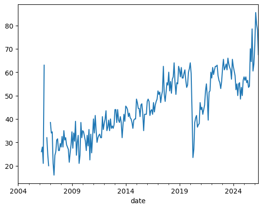

```python
df_gt['gt_mean'].plot()
```

Keep only the mean variable

```python
df_gt = df_gt[['gt_mean']]
df_gt.head(5)
```

| date | gt_mean |
| --- | --- |
| 2004-01-01 | NaN |
| 2004-02-01 | NaN |
| 2004-03-01 | NaN |
| 2004-04-01 | NaN |
| 2004-05-01 | NaN |

**Seasonal Adjustment**

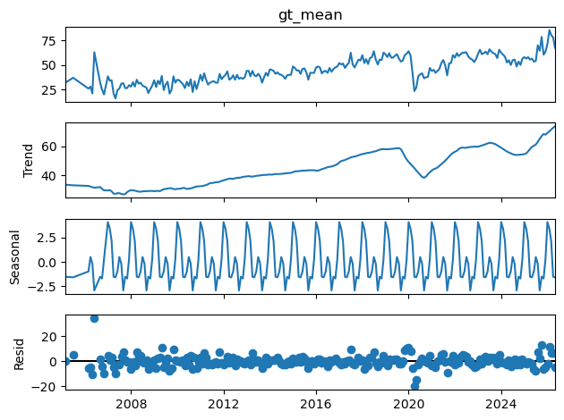

```python
from statsmodels.tsa.seasonal import seasonal_decompose   # import a specific function from a submodule

seasonal_decompose(
    df_gt["gt_mean"].dropna(), model='additive', extrapolate_trend='freq', period=12
    ).plot();    # chaining .plot() directly on the decomposition result displays all four components
```

`seasonal_decompose()` splits a time series into its structural parts. The key arguments here are:

- **`model='additive'`**: assumes the components add together — appropriate when the seasonal swings stay roughly the same size over time. Use `'multiplicative'` if they grow with the level of the series.
- **`period=12`**: tells the function one seasonal cycle = 12 observations (i.e. one year of monthly data).
- **`extrapolate_trend='freq'`**: the trend is estimated with a moving average, which leaves `NaN` at the first and last few observations. This fills those gaps by linearly extrapolating from the nearest valid values.

The decomposition assumes:

$$Y_t = \text{Trend}_t + \text{Seasonal}_t + \text{Residual}_t$$

- **Trend**: the long-run direction of the series
- **Seasonal**: a repeating pattern within each year
- **Residual**: what is left after removing trend and seasonality

We seasonally adjust by subtracting the seasonal component:

$$\text{Adjusted}_t = Y_t - \text{Seasonal}_t = \text{Trend}_t + \text{Residual}_t$$

```python
# Subtract the seasonal component from the raw series to get the seasonally adjusted values
# .seasonal is an attribute on the decomposition result — it is a Series aligned to the same dates
df_gt["gt_mean_adjusted"] = df_gt["gt_mean"] - seasonal_decompose(
      df_gt["gt_mean"].dropna(), model='additive', extrapolate_trend='freq', period=12
  ).seasonal

df_gt.head(5)
```

| date | gt_mean | gt_mean_adjusted |
| --- | --- | --- |
| 2004-01-01 | NaN | NaN |
| 2004-02-01 | NaN | NaN |
| 2004-03-01 | NaN | NaN |
| 2004-04-01 | NaN | NaN |
| 2004-05-01 | NaN | NaN |

Plot google trends data and compare the unadjusted and adjusted series

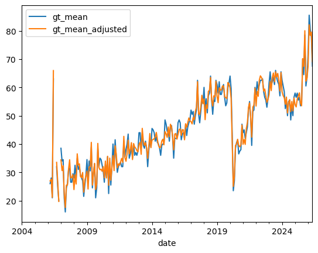

```python
# YOUR CODE HERE: plot both gt_mean and gt_mean_adjusted on the same chart to compare them
df_gt[['gt_mean', 'gt_mean_adjusted']].plot()
```

Keep column of interest and rename

```python
# Keep only adjusted data
# List comprehension: [ expression for item in iterable if condition ] — builds a new list by filtering column names
df_gt = df_gt[[ col for col in df_gt.columns if "adjusted" in col or "RGDP" in col ]]
# Eliminate _adjusted suffix
# .columns returns the current column names; we reassign it to a new list with the suffix removed
df_gt.columns = [ col.replace("_adjusted","") for col in df_gt.columns ]
df_gt.head(5)
```

| date | gt_mean |
| --- | --- |
| 2004-01-01 | NaN |
| 2004-02-01 | NaN |
| 2004-03-01 | NaN |
| 2004-04-01 | NaN |
| 2004-05-01 | NaN |

## NTL data

Load data_ntl_shape.csv and repeat

```python
df_ntl = pd.read_csv(f"{PATH_RAW}/data_ntl_shape.csv", parse_dates=True, index_col='date')
df_ntl = df_ntl[['ntl_mean']]    # keep only the ntl_mean column (double brackets preserve DataFrame structure)
# .resample('MS') groups data by month-start frequency; .mean() averages any rows that fall in the same month
df_ntl = df_ntl.resample('MS').mean()
df_ntl.head(5)
```

| date | ntl_mean |
| --- | --- |
| 2012-01-01 | 1.695293 |
| 2012-02-01 | 1.659527 |
| 2012-03-01 | 1.663169 |
| 2012-04-01 | 1.717300 |
| 2012-05-01 | 1.671262 |

**Seasonal adjustment:** Apply the same code as above

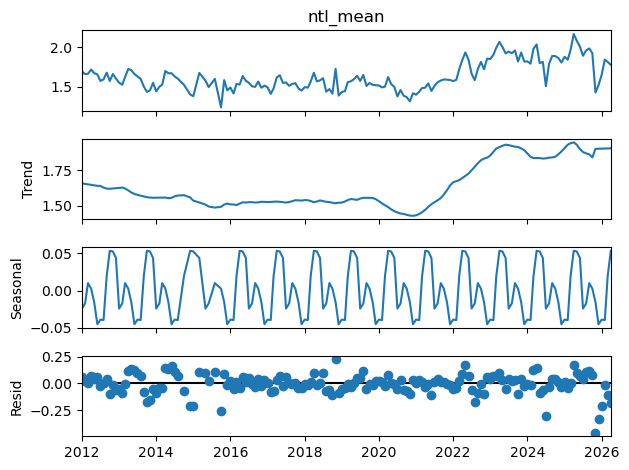

```python
# YOUR CODE HERE: decompose df_ntl["ntl_mean"] — copy the seasonal_decompose() call from the Google Trends section above
# Remember to pass model='additive', extrapolate_trend='freq', period=12
seasonal_decompose(
    df_ntl["ntl_mean"].dropna(), model='additive', extrapolate_trend='freq', period=12
    ).plot();
```

```python
# YOUR CODE HERE: subtract the seasonal component from ntl_mean, just like we did for gt_mean above
df_ntl["ntl_mean_adjusted"] = df_ntl["ntl_mean"] - seasonal_decompose(
    df_ntl["ntl_mean"].dropna(), model='additive', extrapolate_trend='freq', period=12
    ).seasonal

df_ntl.head(5)
```

| date | ntl_mean | ntl_mean_adjusted |
| --- | --- | --- |
| 2012-01-01 | 1.695293 | 1.719620 |
| 2012-02-01 | 1.659527 | 1.676972 |
| 2012-03-01 | 1.663169 | 1.653183 |
| 2012-04-01 | 1.717300 | 1.714756 |
| 2012-05-01 | 1.671262 | 1.687074 |

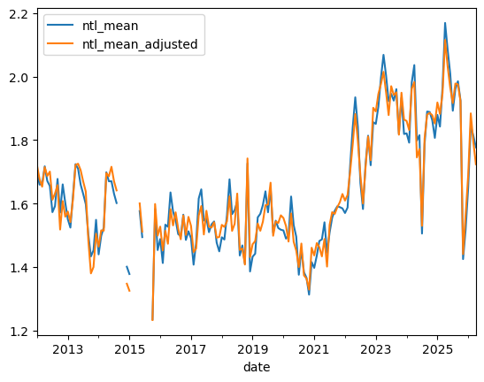

```python
df_ntl.plot()
```

```python
# Keep only adjusted data
# List comprehension filters column names: keep a column if its name contains "adjusted" or "RGDP"
df_ntl = df_ntl[[ col for col in df_ntl.columns if "adjusted" in col or "RGDP" in col ]]
# Eliminate _adjusted suffix
df_ntl.columns = [ col.replace("_adjusted","") for col in df_ntl.columns ]
df_ntl.head(5)
```

| date | ntl_mean |
| --- | --- |
| 2012-01-01 | 1.719620 |
| 2012-02-01 | 1.676972 |
| 2012-03-01 | 1.653183 |
| 2012-04-01 | 1.714756 |
| 2012-05-01 | 1.687074 |

# Merge Together

1. Merge together all data
2. Apply resample

```python
# pd.concat() stacks multiple DataFrames together; axis=1 means "side by side" (join columns), axis=0 would stack rows
# .sort_index() sorts rows by the date index in ascending order
data = pd.concat([ df , df_gt, df_ntl ] , axis=1).sort_index()
data.tail(5)    # .tail(n) shows the last n rows
```

| date | RGDP0000 | gt_mean | ntl_mean |
| --- | --- | --- | --- |
| 2026-01-01 | NaN | 67.404552 | 1.690119 |
| 2026-02-01 | NaN | 82.094802 | 1.884240 |
| 2026-03-01 | NaN | 78.359010 | 1.794314 |
| 2026-04-01 | NaN | 79.529241 | 1.723841 |
| 2026-05-01 | NaN | 69.085376 | NaN |

Resample the dataframe for all columns using the mean

```python
# YOUR CODE HERE: resample to quarterly frequency (use 'QS' for quarter-start) and take the mean
# Example: data.resample('QS').mean()
data = data.resample('QS').mean()
data
```

| date | RGDP0000 | gt_mean | ntl_mean |
| --- | --- | --- | --- |
| 2004-01-01 | NaN | NaN | NaN |
| 2004-04-01 | NaN | NaN | NaN |
| 2004-07-01 | NaN | NaN | NaN |
| 2004-10-01 | NaN | NaN | NaN |
| 2005-01-01 | NaN | 33.529241 | NaN |
| ... | ... | ... | ... |
| 2025-04-01 | 437133.0 | 56.532319 | 2.037228 |
| 2025-07-01 | 438665.0 | 63.701667 | 1.956878 |
| 2025-10-01 | 406765.0 | 68.479893 | 1.642520 |
| 2026-01-01 | NaN | 75.952788 | 1.789558 |
| 2026-04-01 | NaN | 74.307309 | 1.723841 |

90 rows × 3 columns

Manage missing values for estimation

```python
# how='any' drops a row if ANY column has a NaN; use how='all' to only drop rows where every column is NaN
# axis=0 means operate on rows (default)
data = data.dropna(how='any', axis=0)
data.head(10)
```

| date | RGDP0000 | gt_mean | ntl_mean |
| --- | --- | --- | --- |
| 2015-01-01 | 376071.0 | 43.452788 | 1.477991 |
| 2015-04-01 | 371294.0 | 45.198985 | 1.556156 |
| 2015-07-01 | 367625.0 | 42.201667 | 1.588397 |
| 2015-10-01 | 369521.0 | 42.979893 | 1.443498 |
| 2016-01-01 | 379026.0 | 44.619454 | 1.497953 |
| 2016-04-01 | 380452.0 | 44.365652 | 1.528984 |
| 2016-07-01 | 382285.0 | 44.868334 | 1.527016 |
| 2016-10-01 | 383727.0 | 48.313226 | 1.540542 |
| 2017-01-01 | 385870.0 | 48.119454 | 1.478401 |
| 2017-04-01 | 386945.0 | 51.032319 | 1.552376 |

Apply growth-rate transformation

```python
# .pct_change() computes (current - previous) / previous for each column — converts levels to growth rates
# .dropna() removes the first row, which becomes NaN after the percentage-change calculation
data = data.pct_change().dropna()
data.head(10)
```

| date | RGDP0000 | gt_mean | ntl_mean |
| --- | --- | --- | --- |
| 2015-04-01 | -0.012702 | 0.040186 | 0.052886 |
| 2015-07-01 | -0.009882 | -0.066314 | 0.020718 |
| 2015-10-01 | 0.005157 | 0.018441 | -0.091224 |
| 2016-01-01 | 0.025722 | 0.038147 | 0.037725 |
| 2016-04-01 | 0.003762 | -0.005688 | 0.020716 |
| 2016-07-01 | 0.004818 | 0.011330 | -0.001287 |
| 2016-10-01 | 0.003772 | 0.076778 | 0.008858 |
| 2017-01-01 | 0.005585 | -0.004011 | -0.040337 |
| 2017-04-01 | 0.002786 | 0.060534 | 0.050037 |
| 2017-07-01 | 0.016444 | 0.065371 | -0.006040 |

## Plot

Showing off more capabilities

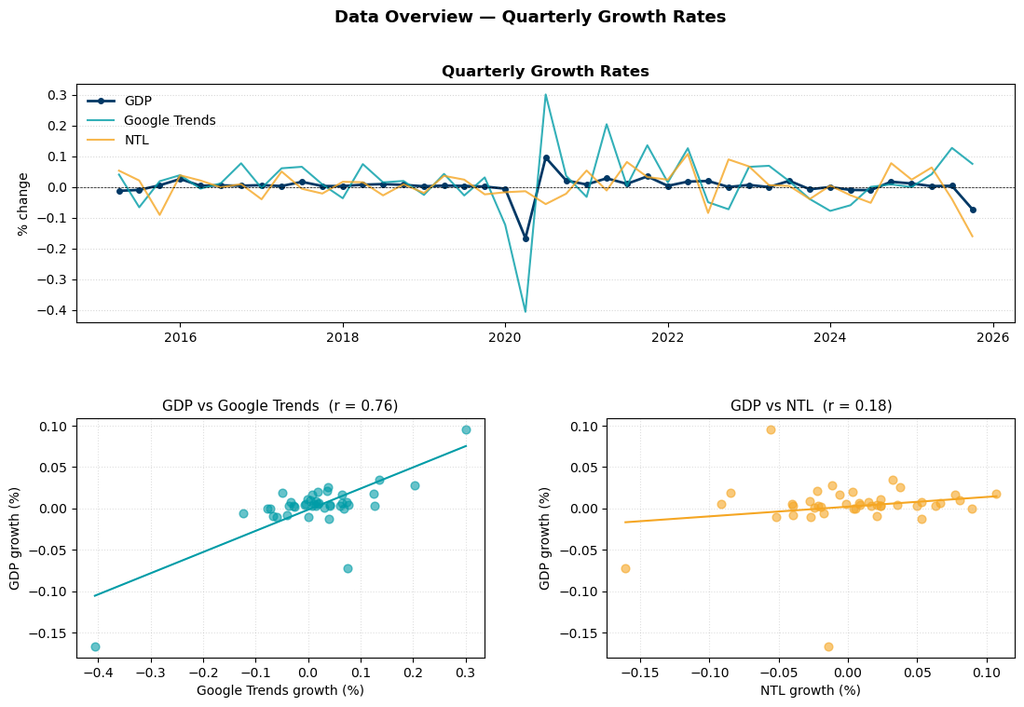

```python
from scipy import stats   # scipy.stats provides statistical functions like linear regression

# figsize=(width, height) sets the figure size in inches
fig = plt.figure(figsize=(13, 8))
# GridSpec divides the figure into a 2x2 grid; hspace/wspace control vertical/horizontal spacing between subplots
gs = fig.add_gridspec(2, 2, hspace=0.4, wspace=0.3)

# Time series — top row, full width
# gs[0, :] means row 0, all columns — this subplot spans the entire top row
ax_ts = fig.add_subplot(gs[0, :])
ax_ts.plot(data['RGDP0000'].dropna(), color='#003865', linewidth=2,
           marker='o', markersize=4, label='GDP')
ax_ts.plot(data['gt_mean'].dropna(), color='#009CA7', linewidth=1.5,
           alpha=0.8, label='Google Trends')    # alpha controls transparency (0=invisible, 1=opaque)
ax_ts.plot(data['ntl_mean'].dropna(), color='#F5A623', linewidth=1.5,
           alpha=0.8, label='NTL')
ax_ts.axhline(0, color='black', linewidth=0.5, linestyle='--')   # draws a horizontal reference line at y=0
ax_ts.set_title('Quarterly Growth Rates', fontsize=12, weight='bold')
ax_ts.set_ylabel('% change')
ax_ts.legend(frameon=False)   # frameon=False removes the box around the legend
ax_ts.grid(axis='y', linestyle=':', alpha=0.5)

# Scatter: GDP vs Google Trends
ax_gt = fig.add_subplot(gs[1, 0])   # gs[1, 0] = row 1, column 0 (bottom-left)
common_gt = data[['RGDP0000', 'gt_mean']].dropna()
# stats.linregress() fits a line y = slope*x + intercept and returns regression statistics
# *_ unpacks and discards the remaining return values (p-value, std error) we don't need here
slope, intercept, r, *_ = stats.linregress(common_gt['gt_mean'], common_gt['RGDP0000'])
# np.linspace(start, stop, n) creates n evenly-spaced values — used to draw a smooth regression line
x_line = np.linspace(common_gt['gt_mean'].min(), common_gt['gt_mean'].max(), 100)
ax_gt.scatter(common_gt['gt_mean'], common_gt['RGDP0000'], color='#009CA7', alpha=0.6, s=40)   # s=40 sets dot size
ax_gt.plot(x_line, intercept + slope * x_line, color='#009CA7', linewidth=1.5)
ax_gt.set_xlabel('Google Trends growth (%)')
ax_gt.set_ylabel('GDP growth (%)')
# f-string embeds the correlation r rounded to 2 decimal places directly in the title
ax_gt.set_title(f'GDP vs Google Trends  (r = {r:.2f})', fontsize=11)
ax_gt.grid(linestyle=':', alpha=0.4)

# Scatter: GDP vs NTL
ax_ntl = fig.add_subplot(gs[1, 1])   # gs[1, 1] = row 1, column 1 (bottom-right)
common_ntl = data[['RGDP0000', 'ntl_mean']].dropna()
slope, intercept, r, *_ = stats.linregress(common_ntl['ntl_mean'], common_ntl['RGDP0000'])
x_line = np.linspace(common_ntl['ntl_mean'].min(), common_ntl['ntl_mean'].max(), 100)
ax_ntl.scatter(common_ntl['ntl_mean'], common_ntl['RGDP0000'], color='#F5A623', alpha=0.6, s=40)
ax_ntl.plot(x_line, intercept + slope * x_line, color='#F5A623', linewidth=1.5)
ax_ntl.set_xlabel('NTL growth (%)')
ax_ntl.set_ylabel('GDP growth (%)')
ax_ntl.set_title(f'GDP vs NTL  (r = {r:.2f})', fontsize=11)
ax_ntl.grid(linestyle=':', alpha=0.4)

fig.suptitle('Data Overview — Quarterly Growth Rates', fontsize=13, weight='bold')
plt.show()
```

## OLS Estimation

We want to estimate how well Google Trends and Nighttime Lights predict GDP growth:

$$\text{GDP growth}_t = \beta_0 + \beta_1 \cdot \text{Google Trends}_t + \beta_2 \cdot \text{NTL}_t + \varepsilon_t$$

There are two common Python libraries for OLS:

| Feature | sklearn | statsmodels |
| --- | --- | --- |
| Purpose | Machine learning / prediction | Statistical inference / econometrics |
| Output | Coefficients only | Coefs + SE, p-values, R2, CIs |
| Syntax | `LinearRegression().fit(X, y)` | `sm.OLS(y, X).fit()` |
| Use when | You want to predict | You want to interpret and test |

**sklearn:**

```
from sklearn.linear_model import LinearRegression
model = LinearRegression().fit(X, y)
print(model.coef_)       # coefficients
print(model.intercept_)  # constant
```

**statsmodels** (used here):

```
import statsmodels.api as sm
model = sm.OLS(y, sm.add_constant(X)).fit()
print(model.summary())
```

For nowcasting we use `statsmodels` because we care about *which indicators matter* and *by how much*, not just prediction.

```python
import statsmodels.api as sm   # statsmodels: library for statistical models with full inference output

y = data['RGDP0000']                              # dependent variable (a pandas Series)
X = sm.add_constant(data[['gt_mean', 'ntl_mean']])  # add_constant() prepends a column of 1s for the intercept term

# sm.OLS(y, X) sets up the model; .fit() estimates coefficients by minimizing sum of squared residuals
model = sm.OLS(y, X).fit()
print(model.summary())   # .summary() prints a full regression table with coefficients, SEs, p-values, and R²
```

```
                            OLS Regression Results
==============================================================================
Dep. Variable:               RGDP0000   R-squared:                       0.611
Model:                            OLS   Adj. R-squared:                  0.592
Method:                 Least Squares   F-statistic:                     31.43
Date:                Mon, 11 May 2026   Prob (F-statistic):           6.25e-09
Time:                        22:15:28   Log-Likelihood:                 105.48
No. Observations:                  43   AIC:                            -205.0
Df Residuals:                      40   BIC:                            -199.7
Df Model:                           2
Covariance Type:            nonrobust
==============================================================================
                 coef    std err          t      P>|t|      [0.025      0.975]
------------------------------------------------------------------------------
const         -0.0022      0.003     -0.648      0.521      -0.009       0.005
gt_mean        0.2561      0.033      7.720      0.000       0.189       0.323
ntl_mean       0.1215      0.065      1.875      0.068      -0.009       0.253
==============================================================================
Omnibus:                       15.894   Durbin-Watson:                   1.942
Prob(Omnibus):                  0.000   Jarque-Bera (JB):               20.580
Skew:                          -1.172   Prob(JB):                     3.40e-05
Kurtosis:                       5.448   Cond. No.                         19.7
==============================================================================

Notes:
[1] Standard Errors assume that the covariance matrix of the errors is correctly specified.
```

## Coefficient Plot

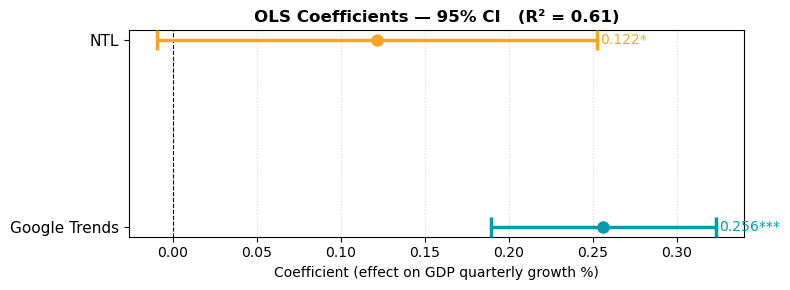

```python
# Coefficient plot with capped confidence intervals
# model.params is a Series of estimated coefficients; .drop('const') removes the intercept
coefs = model.params.drop('const')
# model.conf_int() returns a DataFrame with columns [lower bound, upper bound] for each coefficient
conf  = model.conf_int().drop('const')

# Dictionaries map variable names to colors and display labels
colors = {'gt_mean': '#009CA7', 'ntl_mean': '#F5A623'}
labels = {'gt_mean': 'Google Trends', 'ntl_mean': 'NTL'}

fig, ax = plt.subplots(figsize=(8, 3))

# enumerate() loops over items while also tracking the index i (used here for vertical position)
for i, var in enumerate(coefs.index):
    ax.errorbar(
        coefs[var], i,                    # x = coefficient value, y = row position
        # xerr expects [[left_error], [right_error]] — distance from the point to each end of the CI bar
        xerr=[[coefs[var] - conf.loc[var, 0]], [conf.loc[var, 1] - coefs[var]]],
        fmt='o', color=colors[var], capsize=7, capthick=2.5,
        markersize=8, linewidth=2.5, zorder=3
    )
    # Conditional expression (ternary): value_if_true if condition else value_if_false, chained for multiple thresholds
    sig = '***' if model.pvalues[var] < 0.01 else ('**' if model.pvalues[var] < 0.05 else ('*' if model.pvalues[var] < 0.1 else ''))
    # f-string formats the coefficient to 3 decimal places and appends the significance stars
    ax.text(conf.loc[var, 1] + 0.002, i, f"{coefs[var]:.3f}{sig}",
            va='center', fontsize=10, color=colors[var])

ax.axvline(0, color='black', linewidth=0.8, linestyle='--')   # vertical reference line at zero
ax.set_yticks(range(len(coefs)))   # set tick positions on the y-axis (one per variable)
# list comprehension builds the tick labels by looking up each variable name in the labels dict
ax.set_yticklabels([labels[v] for v in coefs.index], fontsize=11)
ax.set_xlabel('Coefficient (effect on GDP quarterly growth %)')
# :.2f inside the f-string formats model.rsquared to 2 decimal places
ax.set_title(f'OLS Coefficients — 95% CI   (R² = {model.rsquared:.2f})',
             fontsize=12, weight='bold')
ax.grid(axis='x', linestyle=':', alpha=0.5)
plt.tight_layout()   # automatically adjusts subplot spacing so labels don't overlap
plt.show()
```

## Actual vs Fitted

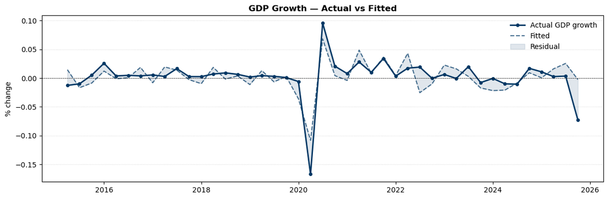

```python
fig, ax = plt.subplots(figsize=(12, 4))

ax.plot(y.index, y, color='#003865', linewidth=2,
        marker='o', markersize=4, label='Actual GDP growth')
# model.fittedvalues is a Series of predicted y values (y-hat) from the regression
ax.plot(model.fittedvalues.index, model.fittedvalues,
        color='#003865', linewidth=1.5, linestyle='--',
        alpha=0.7, label='Fitted')
# fill_between() shades the area between two lines — here, between actual and fitted (the residual gap)
ax.fill_between(y.index, y, model.fittedvalues,
                alpha=0.12, color='#003865', label='Residual')
ax.axhline(0, color='black', linewidth=0.5, linestyle='--')
ax.set_title('GDP Growth — Actual vs Fitted', fontsize=12, weight='bold')
ax.set_ylabel('% change')
ax.legend(frameon=False)
ax.grid(axis='y', linestyle=':', alpha=0.5)
plt.tight_layout()
plt.show()
```

## Standardized Coefficients

Running the same regression on **standardized variables** (each variable minus its mean, divided by its standard deviation).

A standardized coefficient tells you: *how many standard deviations does GDP growth change when the predictor increases by one standard deviation?*

This makes the two coefficients directly comparable, even though Google Trends and NTL are measured in completely different units.

```python
# Standardize: subtract the mean and divide by the standard deviation for each column
# .mean() and .std() operate column-wise by default, returning one value per column
data_std = (data - data.mean()) / data.std()

y_std = data_std['RGDP0000']
X_std = sm.add_constant(data_std[['gt_mean', 'ntl_mean']])

model_std = sm.OLS(y_std, X_std).fit()
print(model_std.summary())
```

```
                            OLS Regression Results
==============================================================================
Dep. Variable:               RGDP0000   R-squared:                       0.611
Model:                            OLS   Adj. R-squared:                  0.592
Method:                 Least Squares   F-statistic:                     31.43
Date:                Mon, 11 May 2026   Prob (F-statistic):           6.25e-09
Time:                        22:15:33   Log-Likelihood:                -40.200
No. Observations:                  43   AIC:                             86.40
Df Residuals:                      40   BIC:                             91.68
Df Model:                           2
Covariance Type:            nonrobust
==============================================================================
                 coef    std err          t      P>|t|      [0.025      0.975]
------------------------------------------------------------------------------
const      -1.388e-17      0.097  -1.42e-16      1.000      -0.197       0.197
gt_mean        0.7612      0.099      7.720      0.000       0.562       0.961
ntl_mean       0.1849      0.099      1.875      0.068      -0.014       0.384
==============================================================================
Omnibus:                       15.894   Durbin-Watson:                   1.942
Prob(Omnibus):                  0.000   Jarque-Bera (JB):               20.580
Skew:                          -1.172   Prob(JB):                     3.40e-05
Kurtosis:                       5.448   Cond. No.                         1.02
==============================================================================

Notes:
[1] Standard Errors assume that the covariance matrix of the errors is correctly specified.
```